# Notice d’utilisation Power BI & Power BI Desktop

BONNEAU Valentin & EKUBA KABUIKU Bénicia

03 avr. 20

# 1 . Power BI

**Power BI** est une solution de Business Intelligence développée par Microsoft pour permettre aux entreprises d’agréger, d’analyser et de visualiser les données provenant des multiples sources mais aussi de partager l’information entre plusieurs personnes. L’interface Power BI se présente comme ci-dessous :

[figure not shown]

**Power BI** est accessible à un utilisateur métier via le *Power BI Service*. C’est un service cloud qui permet de centraliser des rapports et des tableaux de bords interactifs via un navigateur web comme présenter ci-dessous. Il va également permettre d’éditer les accès aux différentes sources de données (sources de données de l’entreprise ou services web).

[figure not shown]

Notons toutefois que ce service *Power BI* fonctionne étroitement avec le client lourd **Power BI Desktop**. Cet outil permet de concevoir en local sur un poste des rapports et des tableaux de bords visuels. Se voulant simple d’utilisation, Power BI desktop comprend un module d’extraction de données, de transformation, de modélisation et de conception de rapports interactifs visuels.

[figure not shown]

## 1.1 Présentation et concept de Power BI

**Power BI Service**

Le *Service cloud de Power BI* permet de :

- Publier les rapports et visualisations de Power BI Desktop et/ou d’autres sources (plus de 50 applications).
- Créer des tableaux de bord personnalisés.
- Partager les visualisations, rapports et tableaux de bords.
- Editer les rafraîchissements de données.

## 1.2 Les fonctionnalités principales de Power BI

Power BI permet :

- La création de rapports et tableaux de bord interactifs et très visuels (il existe de nombreuses visualisations natives ou à télécharger).
- La création de rapports à partir de différentes sources de données : Fichier (Excel, csv, JSON,…), bases de données (SQL Server, Analysis Services, SAP HANA,…), Azure (Azure HDInsight, Azure SQL Data Warehouse, …), services en ligne (Google Analytics, Facebook, dynamics CRM onlne, …).
- La possibilité de créer des modèles de rapport.
- La publication, centralisation et facilité d’accès des rapports sur le service web.
- La visualisation des reportings sur plusieurs devices via Power BI Mobile.

# 2 . Power BI desktop

## 2.1 Utilisation

**Power BI Desktop** est une application gratuite qui s’installe sur un ordinateur local et permet de se connecter à des données, de les transformer et de les visualiser.

Avec Power BI Desktop, nous pouvons nous connecter à plusieurs sources de données différentes et les combiner dans un modèle de données (ce qui correspond à la modélisation). Ce modèle de données nous permet de créer des visuels et des collections de visuels que nous pouvons partager sous forme de rapports avec d’autres personnes au sein de notre entreprise. La plupart des utilisateurs qui travaillent sur des projets d’informatique décisionnelle utilisent Power BI Desktop pour créer des rapports, puis le service Power BI pour les partager avec d’autres personnes.

Voici les utilisations les plus courantes de Power BI Desktop :

• Se connecter aux données

• Transformer et nettoyer ces données pour créer un modèle de données

• Créer des visuels, par exemple, des graphiques, qui donnent des représentations visuelles des données

• Créer des rapports correspondant à des collections de visuels, sur une ou plusieurs pages de rapport

• Partager des rapports avec d’autres utilisateurs à l’aide du service Power BI

En somme, Power BI Desktop nous permet de créer des rapports attrayants, ou d’extraire des données provenant de différentes sources, de générer des modèles de données et de les partager avec nos collègues et notre entreprise.

## 2.2 Présentation de l’interface Power BI Desktop

Trois vues sont disponibles dans Power BI Desktop, que nous sélectionnons sur le côté gauche du canevas. Les vues, montrées dans leur ordre d’apparition, sont les suivantes :

- **Rapport** : Dans cette vue, nous créons des rapports et des visuels ; c’est là que nous passerons la majeure partie de notre temps de création.
- **Données** : Dans cette vue, nous voyons les tables, les mesures et les autres données utilisées dans le modèle de données associé à notre rapport, et nous transformons les données pour une utilisation optimale dans le modèle du rapport.
- **Modèle** : Dans cette vue, nous pouvons afficher et gérer les relations entre les tables de notre modèle de données.

L’illustration suivante montre les trois vues, telles qu’elles apparaissent sur le côté gauche du canevas :

[figure not shown]

# 3 . Méthode d’utilisation

## 3.1 Comment charger les données dans Power BI desktop?

La première chose à faire pour bien démarrer avec Power BI Desktop est de se connecter aux données. De nombreuses sources de données sont accessibles avec Power BI Desktop telles que des fichiers (Excel, csv, JSON,…), bases de données (SQL Server, Analysis Services, SAP HANA,…), Azure (Azure HDInsight, Azure SQL Data Warehouse, …), services en ligne (Google Analytics, Facebook, dynamics CRM onlne, …)

Pour se connecter à des données :

1. Dans le ruban **Accueil**, sélectionnez **Obtenir les données** > **Plus**.

[figure not shown]

La fenêtre **Obtenir les données** s’affiche, indiquant le vaste éventail de catégories auxquelles Power BI Desktop peut se connecter.

2. Lorsque nous sélectionnons un type de données par exemple une base de données SQL, une fenêtre nous invite à entrer les informations, comme par exemple, l’URL et les informations d’identification, nécessaires pour que Power BI Desktop puisse se connecter à la source de données en notre nom.

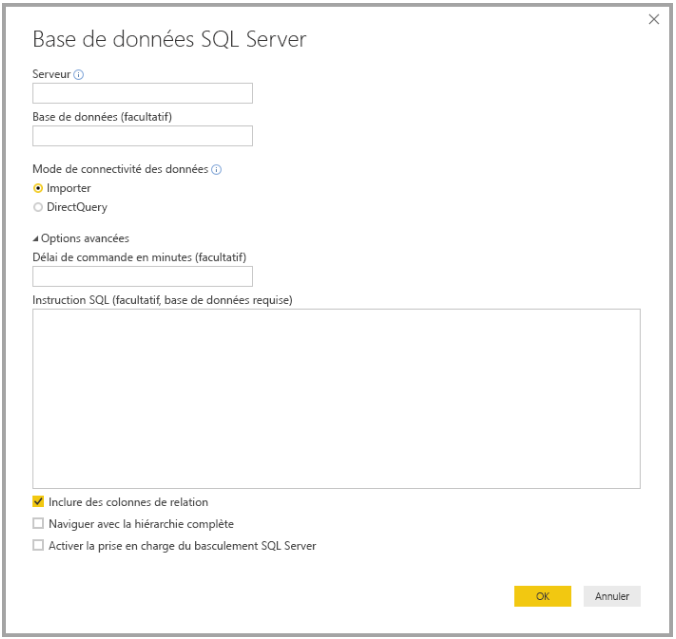

## 3.2 Transformation et nettoyage des données, création d’un modèle de données

Dans Power BI Desktop, nous pouvons nettoyer et transformer les données à l’aide de l’*éditeur Power Query* intégré. Ce dernier permet d’apporter des modifications aux données, par exemple, changer un type de données, supprimer des colonnes ou combiner des données provenant de plusieurs sources. C’est comme de la sculpture : nous partons d’un gros bloc des données, puis nous enlevons certaines parties ou en ajoutons d’autres selon les endroits, jusqu’à atteindre la forme souhaitée ou encore la base des données parfaite pour notre analyse.

Pour démarrer l’éditeur Power Query :

Sélectionnons **Transformer les données** > **Transformer les données** à partir du ruban **Accueil**.

La fenêtre **Éditeur Power Query** s’affiche comme ci-dessous:

[figure not shown]

Chaque étape que nous effectuons pour transformer des données (par exemple, renommer une table, transformer un type de données ou supprimer une colonne) est enregistrée par l’éditeur Power Query. Ces étapes sont effectuées chaque fois que la requête se connecte à la source de données, si bien que les données sont toujours mises en forme comme nous le spécifions.

L’illustration suivante montre la fenêtre **Éditeur Power Query** d’une requête mise en forme et transformée en modèle.

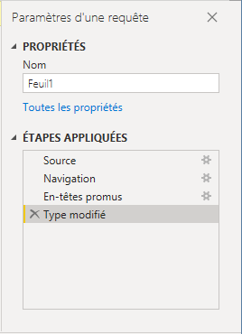

## 3.3 Création des éléments visuels

Après avoir chargé les données, Power BI Desktop crée une feuille à partir de ces données et la met à notre disposition dans le volet Champs. Dans l’image suivante, Power BI Desktop présente ma nouvelle table, appelée **Feuil1**, et les différents champs qui ont été créés dans cette table.

Une fois le modèle de données élaboré, nous pouvons faire glisser des champs vers le canevas de rapport pour créer des visuels. Un visuel est une représentation graphique des données du modèle. Power BI Desktop propose de nombreux types de visuels comme l’illustre l’image suivante (dans **visualisations**) et permet également d’importer des nouveaux visuels à partir de **AppSource** (dans l’encadré avec les 3 petits points).

Ainsi l’on peut créer selon le besoin de notre étude : des histogrammes, des camemberts, des matrices de corrélations, des cartes, des nuages de points, des nuages de mots, etc.

[figure not shown]

**Exemples des visuels que l’on peut générer avec Power BI Desktop**:

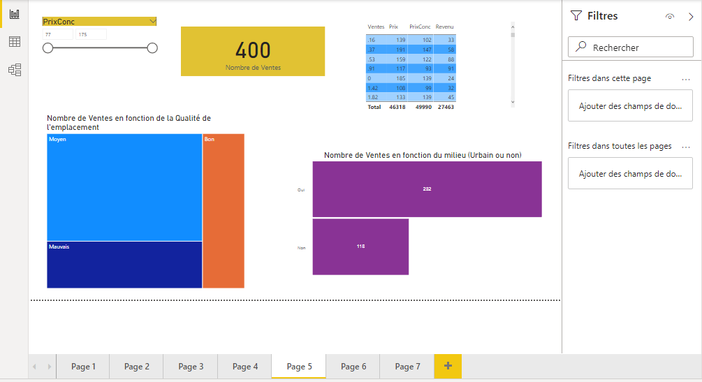

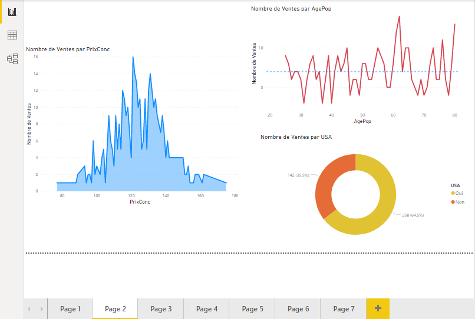

## 3.4 Survoler pour afficher les détails

Les mosaïques sur un tableau de bord sont bien plus que des images. On peut placer **la souris** sur une mosaïque pour afficher des détails sur les données derrière l’objet visuel sur les tableaux de bord et les rapports.

[figure not shown]

Les visuels sont créés par les concepteurs de rapports et de tableaux de bord, puis partagés avec les consommateurs. En tant que consommateur, nous pouvons choisir d’afficher, d’exporter et d’analyser les données qui ont été utilisées pour créer chaque visuel.

## 3.5 Ajout des boutons

**Power BI Desktop** permet de créer des boutons à l’intérieur d’une page. Pour ce faire, il faut afficher les sections **Sélection** et **Signet**.

[figure not shown]

Il faut ensuite insérer un bouton vide, puis rendre visible seulement les graphiques souhaités dans le module **Sélection** précedemment ajouté (en cliquant sur l’oeil pour enlever les graphiques n’apparaissant pas lors de l’action du bouton). Dans le module **Signets** cliquer sur ajouter.

[figure not shown]

Il faut ensuite sélectionner le bouton voulu et se rendre dans l’onglet action dans le module **visualisation** remplir le champs *Type* par *Signet* et le champs *Signet* par *le nouveau Signet* créé.

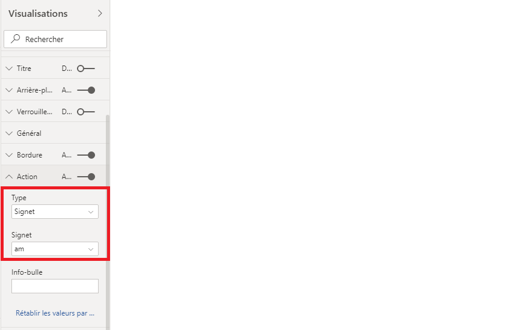

# 4 . Power BI & RStudio

## 4.1 Comment exécuter des scripts R dans Power BI Desktop?

Nous pouvons exécuter des scripts R directement dans Power BI Desktop et importer les jeux de données obtenus dans un modèle de données Power BI Desktop.

**Pour pouvoir exécuter des scripts R dans Power BI Desktop, il faut premièrement installer R sur son ordinateur local.**

## 4.2 Comment créer des visuels avec Power BI avec R?

### 4.2.1 Activation des visuels R dans Power BI Desktop

Une fois que nous avons installé R, Power BI Desktop l’active automatiquement. Pour vérifier que Power BI Desktop a activé R à l’emplacement approprié, procédons comme suit :

- Dans le menu Power BI Desktop, sélectionnons **Fichier** > **Options et paramètres** > **Options**.
- Sur le côté gauche de la page **Options**, sous **Global**, sélectionnons **Script R**.
- Sous **Options de script R**, vérifions que notre installation R locale est spécifiée dans **Répertoires de base R détectés** et qu’elle reflète correctement l’installation R locale que nous voulons que Power BI Desktop utilise. Dans l’image suivante, le chemin de l’installation locale de R est indiqué comme ci-dessous :

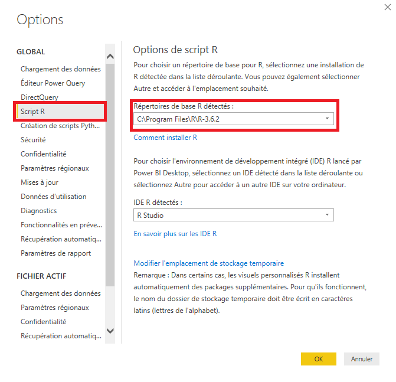

Après avoir vérifié notre installation R, nous pouvons commencer à créer des visuels R.

### 4.2.2 Création des visuels R dans Power BI Desktop

1. Sélectionnons l’icône **Visuel R** dans le volet **Visualisations** pour ajouter un visuel R.

[figure not shown]

2. Dans la boîte de dialogue **Activer les éléments visuels de script** qui s’affiche, sélectionnons **Activer**.

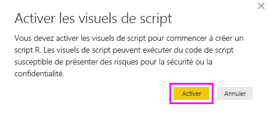

Quand nous ajoutons un visuel R à un rapport, Power BI Desktop effectue les modifications suivantes :

- Une image de visuel R apparaît sous forme d’espace réservé sur le canevas de rapport.
- **L’Éditeur de script R** s’affiche dans la partie inférieure du volet central comme l’illustre l’image ci-dessous.

[figure not shown]

3. Dans la section **Valeurs** du volet **Visualisations**, faisons glisser les champs du volet **Champs** que nous voulons utiliser dans notre script R, comme nous le ferions avec n’importe quel autre visuel Power BI Desktop. Nous pouvons aussi sélectionner les champs directement dans le volet **Champs**.

Seuls les champs que nous avons ajoutés à la section **Valeurs** sont disponibles pour notre script R. Nous pouvons ajouter de nouveaux champs ou supprimer les champs inutiles de la section **Champs** pendant que nous travaillons sur notre script R dans **l’Éditeur de scripts R**.

Power BI Desktop détecte automatiquement les champs que nous avons ajoutés ou supprimés.

4. Nous pouvons à présent utiliser les données sélectionnées pour créer un tracé :
- Quand nous sélectionnons des champs, **l’Éditeur de script R** génère du code de liaison au script R pour ces champs dans la section grise située en haut du volet de l’éditeur.
- Si nous supprimons un champ, **l’Éditeur de script R** supprime automatiquement le code de prise en charge pour ce champ.

Dans l’exemple présenté dans l’image suivante, tous nos champs sont sélectionnés. Suite à ces sélections, **l’Éditeur de script R** a généré du code de liaison, qui peut être résumé comme suit :

- Créons un dataframe appelé **jeu de données(dataset)**, qui se compose des différents champs sélectionnés par l’utilisateur.
- L’agrégation par défaut est *Ne pas synthétiser*.
- À l’instar des visuels de table, les champs sont regroupés et les lignes en double n’apparaissent qu’une fois.

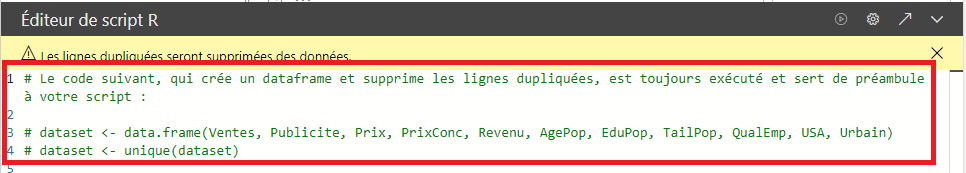

Le dataframe généré est appelé **jeu de données**(ou dataset) et nous pouvons accéder aux colonnes sélectionnées par leurs noms respectifs. Par exemple, nous pouvons accéder au champ « Prix » en ajoutant *dataset$Prix* à notre script R. Pour les champs avec des espaces ou des caractères spéciaux, nous devons utiliser des guillemets simples.

5. Une fois le dataframe généré automatiquement par les champs que nous avons sélectionnés, nous pouvons écrire un script R dont Power BI Desktop trace le résultat sur le périphérique R par défaut. Une fois le script terminé, nous sélectionnons **Exécuter le script** sur le côté droit de la barre de titre de **l’Éditeur de script R**.

Quand nous sélectionnons **Exécuter le script**, Power BI Desktop identifie le tracé et le présente sur le *canevas*. Le processus étant exécuté sur l’installation locale de R, il faut vérifier que les packages R nécessaires sont installés.

Power BI Desktop retrace le visuel lorsque l’un des événements suivants se produit :

- Nous sélectionnons **Exécuter le script** dans la barre de titre de l’Éditeur de script R.
- Une modification des données se produit en raison de l’actualisation, du filtrage ou de la mise en surbrillance de données.

On peut également lancer le script dans *R* en cliquant sur le bouton **Modifier le script dans l’IDE externe** qui se trouve à droite de la barre de titre **Éditeur de script R**, comme indiqué ci-dessous.

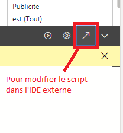

Après avoir cliqué sur le bouton comme indiqué ci-dessus, Power BI Desktop ouvre notre environnement de développement *R* où **RStudio** est l’IDE R par défaut.

*Power BI Desktop* ajoute les trois premières lignes du script afin qu’il puisse importer les données à partir de **Power BI Desktop** une fois que nous exécutons le script contenant la base de données créée dans Power BI Desktop comme nous pouvons le voir dans l’image ci-dessous :

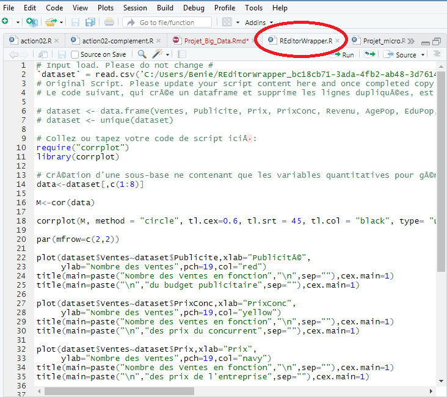

Les scripts que nous avons créés dans le volet **Éditeur de script R** de **Power BI Desktop** apparaissent à partir de la ligne 4 de notre IDE R. À ce stade, nous pouvons créer notre script R dans l’IDE R comme l’illustre l’image ci-dessus. Une fois que notre script R est terminé dans notre IDE R, nous devons le copier et le coller dans le volet **Éditeur de script R** de **Power BI Desktop**, *à l’exclusion* des trois premières lignes du script générées automatiquement par **Power BI Desktop**. Il ne faut en aucun cas récopier les trois premières lignes du script dans **Power BI Desktop** puisque ces lignes ont été utilisées uniquement pour importer les données dans notre IDE R à partir de **Power BI Desktop**.

L’image suivante montre un exemple de code de tracé de corrélation, qui représente les corrélations entre nos différentes variables quantitatives.

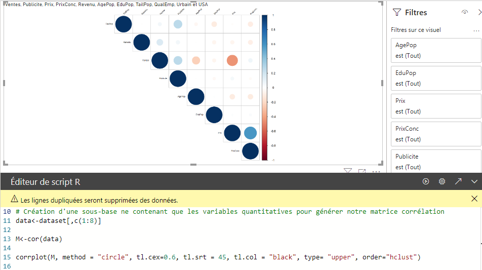

On peut générer différents graphiques tels que des nuages de point ou encore des boxplots avec les codes R que nous avons copiés et collés dans le volet **Éditeur de script R** de **Power BI Desktop**.

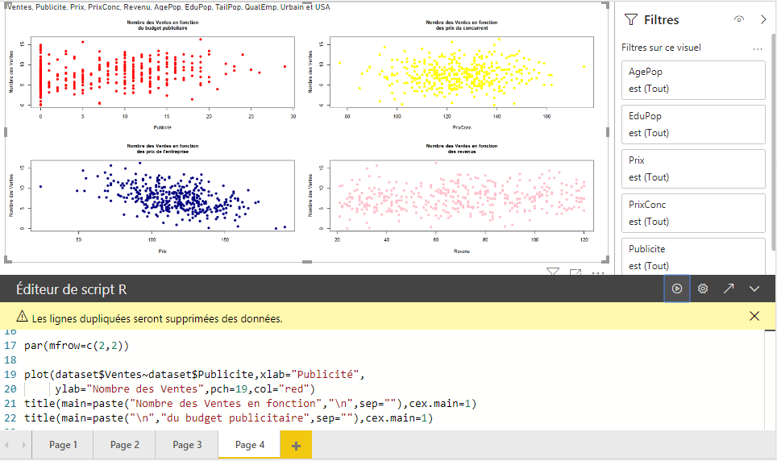

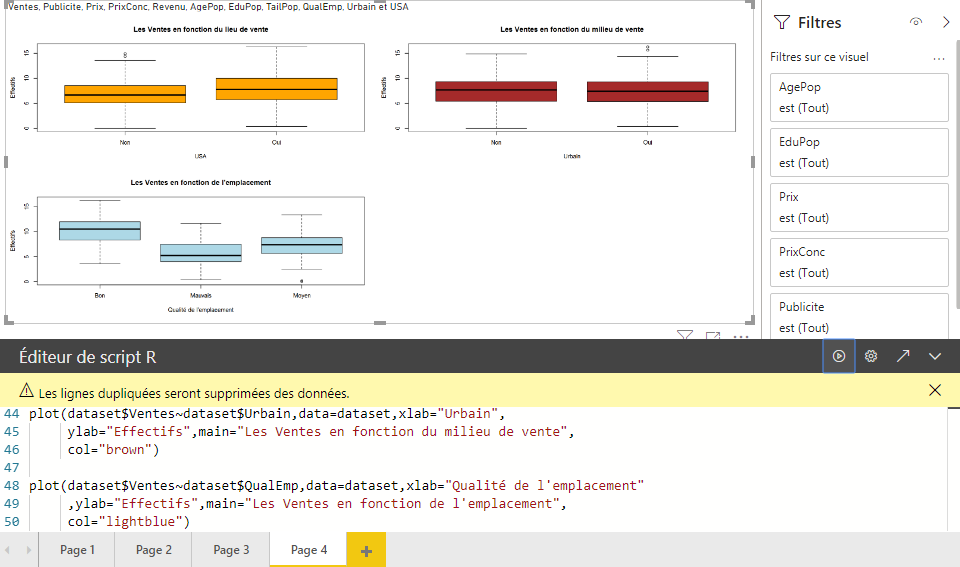

### 4.2.3 Quelques limites des visuels R dans Power BI Desktop

Les visuels R dans Power BI Desktop ont ces quelques limitations telles que:

- La tailles des données : Les données utilisées par un visuel R pour le traçage sont limitées à 150 000 lignes. Si plus de 150 000 lignes sont sélectionnées, seules les 150 000 premières lignes sont utilisées et un message s’affiche sur l’image.
- Le temps de calcul : Si un calcul visuel R dépasse cinq minutes, il provoque une erreur de délai d’expiration, etc.

# 5 . Le partarge des rapports

Une fois que le rapport est prêt à être partagé avec d’autres utilisateurs, nous pouvons le **publier** sur le service Power BI et le mettre à la disposition de tous les collaborateurs de notre entreprise qui possèdent une licence Power BI.

Pour publier un rapport Power BI Desktop :

1. Dans le ruban Accueil, sélectionnons **Publier**.

[figure not shown]

Power BI Desktop nous connecte au service Power BI avec notre compte Power BI.

2. Power BI nous invite à sélectionner l’emplacement dans le service Power BI où nous souhaitons partager le rapport, comme notre espace de travail, un espace de travail d’équipe ou un autre emplacement dans le service Power BI.

Nous devons disposer d’une licence Power BI pour pouvoir partager des rapports sur le service Power BI.

Une fois le rapport partagé sur Power BI, on peut à nouveau effectuer les modifications que nous souhaitons dans ce rapport puisque nous avons un onglet **modifier le rapport** dans **notre espace de travail Power BI**, et nous pouvons également générer des nouveaux visuels. Dans notre espace de travail Power BI, nous retrouvons tous nos éléments de visuel ainsi que nos données comme nous le montre l’image ci-dessous.

[figure not shown]